# Quantium task 2

```python
import numpy as np
import pandas as pd
import matplotlib.pyplot as plt
import seaborn as sns
from scipy.stats import t

import warnings
warnings.filterwarnings('ignore')
```

```python
data = pd.read_csv("C:/Users/Guoli/Documents/Data Science Material/Projects/Quantium/QVI_data.csv")
data.head(3)
```

|  | LYLTY_CARD_NBR | DATE | STORE_NBR | TXN_ID | PROD_NBR | PROD_NAME | PROD_QTY | TOT_SALES | PACK_SIZE | BRAND | LIFESTAGE | PREMIUM_CUSTOMER |
| --- | --- | --- | --- | --- | --- | --- | --- | --- | --- | --- | --- | --- |
| 0 | 1000 | 2018-10-17 | 1 | 1 | 5 | Natural Chip Compny SeaSalt175g | 2 | 6.0 | 175 | NATURAL | YOUNG SINGLES/COUPLES | Premium |
| 1 | 1002 | 2018-09-16 | 1 | 2 | 58 | Red Rock Deli Chikn&Garlic Aioli 150g | 1 | 2.7 | 150 | RRD | YOUNG SINGLES/COUPLES | Mainstream |
| 2 | 1003 | 2019-03-07 | 1 | 3 | 52 | Grain Waves Sour Cream&Chives 210G | 1 | 3.6 | 210 | GRNWVES | YOUNG FAMILIES | Budget |

```python
data.shape
```

```
(264834, 12)
```

```python
#check for null values

data.isnull().sum()
```

```
LYLTY_CARD_NBR      0
DATE                0
STORE_NBR           0
TXN_ID              0
PROD_NBR            0
PROD_NAME           0
PROD_QTY            0
TOT_SALES           0
PACK_SIZE           0
BRAND               0
LIFESTAGE           0
PREMIUM_CUSTOMER    0
dtype: int64
```

## Select control stores

The client has selected store numbers 77, 86 and 88 as trial stores and want control stores to be established stores that are operational for the entire observation period.

We would want to match trial stores to control stores that are similar to the trial store prior to the trial period of Feb 2019 in terms of :

- Monthly overall sales revenue
- Monthly number of customers
- Monthly number of transactions per customer Let's first create the metrics of interest and filter to stores that are present throughout the pre-trial period.

```python
# Create 'YEARMONTH' feature

data['DATE'] = pd.to_datetime(data['DATE']) # convert string Date time into Python Date time object.

data['Year_Month'] = [x.year * 100 + x.month  for x in data['DATE']]
```

```python
data.head(3)
```

|  | LYLTY_CARD_NBR | DATE | STORE_NBR | TXN_ID | PROD_NBR | PROD_NAME | PROD_QTY | TOT_SALES | PACK_SIZE | BRAND | LIFESTAGE | PREMIUM_CUSTOMER | Year_Month |
| --- | --- | --- | --- | --- | --- | --- | --- | --- | --- | --- | --- | --- | --- |
| 0 | 1000 | 2018-10-17 | 1 | 1 | 5 | Natural Chip Compny SeaSalt175g | 2 | 6.0 | 175 | NATURAL | YOUNG SINGLES/COUPLES | Premium | 201810 |
| 1 | 1002 | 2018-09-16 | 1 | 2 | 58 | Red Rock Deli Chikn&Garlic Aioli 150g | 1 | 2.7 | 150 | RRD | YOUNG SINGLES/COUPLES | Mainstream | 201809 |
| 2 | 1003 | 2019-03-07 | 1 | 3 | 52 | Grain Waves Sour Cream&Chives 210G | 1 | 3.6 | 210 | GRNWVES | YOUNG FAMILIES | Budget | 201903 |

Next, we define the measure calculations to use during the analysis. For each store and month calculate:

```python
measures = data.groupby(['STORE_NBR', 'Year_Month']).agg({'TOT_SALES':'sum', 'LYLTY_CARD_NBR':'nunique', 'TXN_ID':'nunique', 'PROD_QTY':'sum' })
measures['Price_Per_Unit'] = measures['TOT_SALES']/measures['PROD_QTY']
measures['Chip_Per_Txn'] = measures['PROD_QTY']/measures['TXN_ID']
measures['Txn_Per_Cust'] = measures['TXN_ID']/measures['LYLTY_CARD_NBR']
measures.drop(['TXN_ID'], axis = 1, inplace = True)

measures
```

| STORE_NBR | Year_Month | TOT_SALES | LYLTY_CARD_NBR | PROD_QTY | Price_Per_Unit | Chip_Per_Txn | Txn_Per_Cust |
| --- | --- | --- | --- | --- | --- | --- | --- |
| 1 | 201807 | 206.9 | 49 | 62 | 3.337097 | 1.192308 | 1.061224 |
|  | 201808 | 176.1 | 42 | 54 | 3.261111 | 1.255814 | 1.023810 |
|  | 201809 | 278.8 | 59 | 75 | 3.717333 | 1.209677 | 1.050847 |
|  | 201810 | 188.1 | 44 | 58 | 3.243103 | 1.288889 | 1.022727 |
|  | 201811 | 192.6 | 46 | 57 | 3.378947 | 1.212766 | 1.021739 |
| ... | ... | ... | ... | ... | ... | ... | ... |
| 272 | 201902 | 395.5 | 45 | 91 | 4.346154 | 1.895833 | 1.066667 |
|  | 201903 | 442.3 | 50 | 101 | 4.379208 | 1.905660 | 1.060000 |
|  | 201904 | 445.1 | 54 | 105 | 4.239048 | 1.909091 | 1.018519 |
|  | 201905 | 314.6 | 34 | 71 | 4.430986 | 1.775000 | 1.176471 |
|  | 201906 | 312.1 | 34 | 70 | 4.458571 | 1.891892 | 1.088235 |

3169 rows × 6 columns

```python
# Which stores do not have full observation i.e. have months where there is no transaction for chips

a = pd.pivot_table(data, index = 'STORE_NBR', columns = 'Year_Month', values = 'TXN_ID', aggfunc = 'count')
a.head()
```

| Year_Month STORE_NBR | 201807 | 201808 | 201809 | 201810 | 201811 | 201812 | 201901 | 201902 | 201903 | 201904 | 201905 | 201906 |
| --- | --- | --- | --- | --- | --- | --- | --- | --- | --- | --- | --- | --- |
| 1 | 52.0 | 43.0 | 62.0 | 45.0 | 47.0 | 47.0 | 36.0 | 55.0 | 49.0 | 43.0 | 51.0 | 43.0 |
| 2 | 41.0 | 43.0 | 37.0 | 43.0 | 40.0 | 38.0 | 45.0 | 32.0 | 46.0 | 49.0 | 50.0 | 42.0 |
| 3 | 138.0 | 134.0 | 119.0 | 119.0 | 118.0 | 129.0 | 121.0 | 139.0 | 130.0 | 110.0 | 123.0 | 122.0 |
| 4 | 160.0 | 151.0 | 138.0 | 155.0 | 139.0 | 133.0 | 168.0 | 102.0 | 135.0 | 137.0 | 126.0 | 134.0 |
| 5 | 120.0 | 112.0 | 125.0 | 107.0 | 111.0 | 125.0 | 118.0 | 106.0 | 97.0 | 109.0 | 104.0 | 127.0 |

```python
a.isnull().sum()
```

```
Year_Month
201807    6
201808    9
201809    8
201810    7
201811    8
201812    9
201901    9
201902    8
201903    7
201904    7
201905    9
201906    8
dtype: int64
```

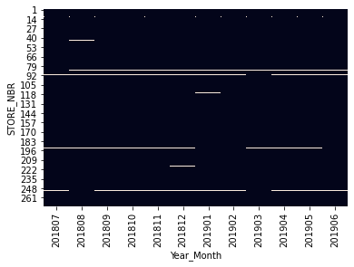

```python
# Let's visualize the null values

sns.heatmap(a.isnull(), cbar = False)
```

We can see that store number 92, 193, 252 around have the most missing values and some other stores too.

```python
# Store numbers that do not have full observation periods

null_stores = a[a.isnull().any(axis=1)].index.tolist()
null_stores
```

```
[11, 31, 44, 76, 85, 92, 117, 193, 206, 211, 218, 252]
```

```python
# Let's drop these stores from 'measures'

measures.shape
```

[output not shown]

```python
measures = measures.rename(columns={'LYLTY_CARD_NBR':'CUSTOMERS'})
measures.head()
```

|  | STORE_NBR | Year_Month | TOT_SALES | CUSTOMERS | PROD_QTY | Price_Per_Unit | Chip_Per_Txn | Txn_Per_Cust |
| --- | --- | --- | --- | --- | --- | --- | --- | --- |
| 0 | 1 | 201807 | 206.9 | 49 | 62 | 3.337097 | 1.192308 | 1.061224 |
| 1 | 1 | 201808 | 176.1 | 42 | 54 | 3.261111 | 1.255814 | 1.023810 |
| 2 | 1 | 201809 | 278.8 | 59 | 75 | 3.717333 | 1.209677 | 1.050847 |
| 3 | 1 | 201810 | 188.1 | 44 | 58 | 3.243103 | 1.288889 | 1.022727 |
| 4 | 1 | 201811 | 192.6 | 46 | 57 | 3.378947 | 1.212766 | 1.021739 |

```python
measures = measures[~measures['STORE_NBR'].isin(null_stores)]
measures.shape
```

```
(3120, 8)
```

```python
# Create new dataframe 'preTrialMeasures'
# Filter to pre-trial period i.e. before 201902

preTrialMeasures = measures.loc[measures['Year_Month'] < 201902, :]
preTrialMeasures.shape
```

```
(1820, 8)
```

```python
preTrialMeasures.head()
```

|  | STORE_NBR | Year_Month | TOT_SALES | CUSTOMERS | PROD_QTY | Price_Per_Unit | Chip_Per_Txn | Txn_Per_Cust |
| --- | --- | --- | --- | --- | --- | --- | --- | --- |
| 0 | 1 | 201807 | 206.9 | 49 | 62 | 3.337097 | 1.192308 | 1.061224 |
| 1 | 1 | 201808 | 176.1 | 42 | 54 | 3.261111 | 1.255814 | 1.023810 |
| 2 | 1 | 201809 | 278.8 | 59 | 75 | 3.717333 | 1.209677 | 1.050847 |
| 3 | 1 | 201810 | 188.1 | 44 | 58 | 3.243103 | 1.288889 | 1.022727 |
| 4 | 1 | 201811 | 192.6 | 46 | 57 | 3.378947 | 1.212766 | 1.021739 |

Create function to calculate correlation for a measure, looping through each control store.

```python
def calcCorr(inputTable, metric, trial_store):
    output = pd.DataFrame({'Store1': [], 'Store2': [], 'Correlation': []})
    a = inputTable.loc[inputTable['STORE_NBR'] == trial_store, metric]
    a.reset_index(drop = True, inplace = True)
    storeNumbers = inputTable['STORE_NBR'].unique()
    for i in storeNumbers:
        b = inputTable.loc[inputTable['STORE_NBR'] == i, metric]
        b.reset_index(drop = True, inplace = True)
        output = output.append({'Store1': trial_store, 'Store2': i, 'Correlation': b.corr(a)}, ignore_index = True)
    return output
```

Apart from correlation, we can also calculate a standardised metric based on the absolute difference between the trial store's performance and each control store's performance.

```python
def standardizer(inputTable, metric, trial_store):
    output = pd.DataFrame({'Store1': [], 'Store2': [], 'Magnitude' : []})
    a = inputTable.loc[inputTable['STORE_NBR'] == trial_store, metric]
    a.reset_index(drop = True, inplace = True)
    storeNumbers = inputTable['STORE_NBR'].unique()
    for i in storeNumbers:
        b = inputTable.loc[inputTable['STORE_NBR'] == i, metric]
        b.reset_index(drop = True, inplace = True)
        c = abs(a-b)
        d = np.mean(1-(c-min(c))/(max(c)-min(c)))
        output = output.append({'Store1': trial_store, 'Store2': i, 'Magnitude': d}, ignore_index = True)
    return output
```

## Find the control stores for trial store 77

We'll select control stores based on how similar monthly total sales in dollar amounts and monthly number of customers are to the trial stores.

```python
trial_store = 77
corr_sale = calcCorr(preTrialMeasures, 'TOT_SALES', trial_store)
corr_cust = calcCorr(preTrialMeasures, 'CUSTOMERS', trial_store)

mag_sale = standardizer(preTrialMeasures, 'TOT_SALES', trial_store)
mag_cust = standardizer(preTrialMeasures, 'CUSTOMERS', trial_store)
```

```python
corr_sale.head(3)
```

|  | Store1 | Store2 | Correlation |
| --- | --- | --- | --- |
| 0 | 77.0 | 1.0 | 0.075218 |
| 1 | 77.0 | 2.0 | -0.263079 |
| 2 | 77.0 | 3.0 | 0.806644 |

```python
corr_cust.head(3)
```

|  | Store1 | Store2 | Correlation |
| --- | --- | --- | --- |
| 0 | 77.0 | 1.0 | 0.322168 |
| 1 | 77.0 | 2.0 | -0.572051 |
| 2 | 77.0 | 3.0 | 0.834207 |

```python
mag_sale.head(3)
```

|  | Store1 | Store2 | Magnitude |
| --- | --- | --- | --- |
| 0 | 77.0 | 1.0 | 0.408163 |
| 1 | 77.0 | 2.0 | 0.590119 |
| 2 | 77.0 | 3.0 | 0.522914 |

```python
mag_cust.head(3)
```

|  | Store1 | Store2 | Magnitude |
| --- | --- | --- | --- |
| 0 | 77.0 | 1.0 | 0.663866 |
| 1 | 77.0 | 2.0 | 0.471429 |
| 2 | 77.0 | 3.0 | 0.489796 |

We'll need to combine the all the scores calculated using our function to create a composite score to rank on.

```python
score_sales = pd.concat([corr_sale, mag_sale['Magnitude']], axis = 1)
score_sales.head(3)
```

|  | Store1 | Store2 | Correlation | Magnitude |
| --- | --- | --- | --- | --- |
| 0 | 77.0 | 1.0 | 0.075218 | 0.408163 |
| 1 | 77.0 | 2.0 | -0.263079 | 0.590119 |
| 2 | 77.0 | 3.0 | 0.806644 | 0.522914 |

Add a simple average on the scores which is 0.5 *corr measures + 0.5* mag measures

```python
score_sales['scoresales'] = 0.5 * corr_sale['Correlation'] + 0.5 * mag_sale['Magnitude']
score_sales.head(3)
```

|  | Store1 | Store2 | Correlation | Magnitude | scoresales |
| --- | --- | --- | --- | --- | --- |
| 0 | 77.0 | 1.0 | 0.075218 | 0.408163 | 0.241691 |
| 1 | 77.0 | 2.0 | -0.263079 | 0.590119 | 0.163520 |
| 2 | 77.0 | 3.0 | 0.806644 | 0.522914 | 0.664779 |

```python
score_custs = pd.concat([corr_cust, mag_cust['Magnitude']], axis = 1)
score_custs['scorecusts'] = 0.5 * corr_cust['Correlation'] + 0.5 * mag_cust['Magnitude']
score_custs.head(3)
```

|  | Store1 | Store2 | Correlation | Magnitude | scorecusts |
| --- | --- | --- | --- | --- | --- |
| 0 | 77.0 | 1.0 | 0.322168 | 0.663866 | 0.493017 |
| 1 | 77.0 | 2.0 | -0.572051 | 0.471429 | -0.050311 |
| 2 | 77.0 | 3.0 | 0.834207 | 0.489796 | 0.662002 |

Combine scores across the drivers by first merging our sales scores and customer scores into a single table

```python
#score_sales.set_index(['Store1', 'Store2'], inplace = True)
#score_custs.set_index(['Store1', 'Store2'], inplace = True)

scores_contral = pd.concat([score_sales['scoresales'], score_custs['scorecusts']], axis = 1)
scores_contral.head()
```

| Store1 | Store2 | scoresales | scorecusts |
| --- | --- | --- | --- |
| 77.0 | 1.0 | 0.241691 | 0.493017 |
|  | 2.0 | 0.163520 | -0.050311 |
|  | 3.0 | 0.664779 | 0.662002 |
|  | 4.0 | 0.190817 | 0.101310 |
|  | 5.0 | 0.202834 | 0.441632 |

```python
scores_contral['finalContralScore'] = 0.5 * scores_contral['scoresales'] + 0.5 * scores_contral['scorecusts']
scores_contral.head()
```

| Store1 | Store2 | scoresales | scorecusts | finalContralScore |
| --- | --- | --- | --- | --- |
| 77.0 | 1.0 | 0.241691 | 0.493017 | 0.367354 |
|  | 2.0 | 0.163520 | -0.050311 | 0.056604 |
|  | 3.0 | 0.664779 | 0.662002 | 0.663390 |
|  | 4.0 | 0.190817 | 0.101310 | 0.146064 |
|  | 5.0 | 0.202834 | 0.441632 | 0.322233 |

```python
scores_contral.sort_values(by = 'finalContralScore', ascending = False).head()
```

| Store1 | Store2 | scoresales | scorecusts | finalContralScore |
| --- | --- | --- | --- | --- |
| 77.0 | 233.0 | 0.697290 | 0.816607 | 0.756949 |
|  | 71.0 | 0.789497 | 0.663123 | 0.726310 |
|  | 84.0 | 0.656972 | 0.715000 | 0.685986 |
|  | 119.0 | 0.636046 | 0.729729 | 0.682887 |
|  | 115.0 | 0.708347 | 0.645155 | 0.676751 |

The store with the highest final score is then selected as the control store since it is most similar to the trial store.

```python
control_store = 233
```

# Visualizing

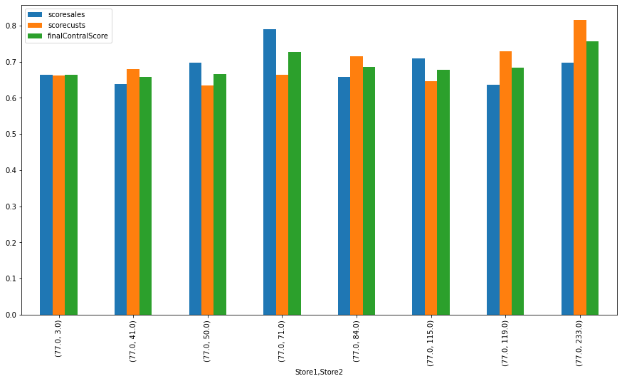

```python
scores_contral[scores_contral.finalContralScore.abs() > 0.65].plot(kind = 'bar', figsize = (15,8))
```

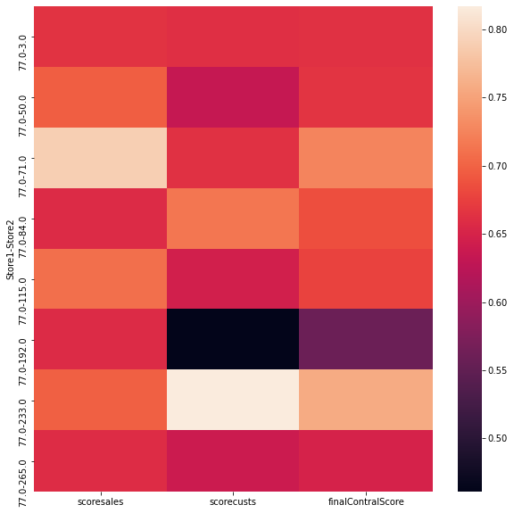

```python
plt.figure(figsize = (10, 10))
sns.heatmap(scores_contral[scores_contral.scoresales.abs()>0.65])
```

Now that we have found a control store, let's check visually if the drivers are indeed similar in the period before the trial.

We'll look at total sales first.

# Visual checks on trends based on the drivers

```python
pastSales = preTrialMeasures

store_type = []

for i in pastSales['STORE_NBR']:
    if i == trial_store:
            store_type.append('Trial Store')
    elif i == control_store:
        store_type.append('Control Store')
    else:
        store_type.append('Other Stores')

pastSales['store_type'] = store_type
pastSales.head()
```

|  | STORE_NBR | Year_Month | TOT_SALES | CUSTOMERS | PROD_QTY | Price_Per_Unit | Chip_Per_Txn | Txn_Per_Cust | store_type |
| --- | --- | --- | --- | --- | --- | --- | --- | --- | --- |
| 0 | 1 | 201807 | 206.9 | 49 | 62 | 3.337097 | 1.192308 | 1.061224 | Other Stores |
| 1 | 1 | 201808 | 176.1 | 42 | 54 | 3.261111 | 1.255814 | 1.023810 | Other Stores |
| 2 | 1 | 201809 | 278.8 | 59 | 75 | 3.717333 | 1.209677 | 1.050847 | Other Stores |
| 3 | 1 | 201810 | 188.1 | 44 | 58 | 3.243103 | 1.288889 | 1.022727 | Other Stores |
| 4 | 1 | 201811 | 192.6 | 46 | 57 | 3.378947 | 1.212766 | 1.021739 | Other Stores |

```python
pastSales['store_type'].unique()
```

```
array(['Other Stores', 'Trial Store', 'Control Store'], dtype=object)
```

```python
pd.value_counts(pastSales['store_type'] == 'Control Store')
```

```
False    1813
True        7
Name: store_type, dtype: int64
```

```python
pastSales.info()
```

```
<class 'pandas.core.frame.DataFrame'>
Int64Index: 1820 entries, 0 to 3114
Data columns (total 9 columns):
 #   Column          Non-Null Count  Dtype
---  ------          --------------  -----
 0   STORE_NBR       1820 non-null   int64
 1   Year_Month      1820 non-null   int64
 2   TOT_SALES       1820 non-null   float64
 3   CUSTOMERS       1820 non-null   int64
 4   PROD_QTY        1820 non-null   int64
 5   Price_Per_Unit  1820 non-null   float64
 6   Chip_Per_Txn    1820 non-null   float64
 7   Txn_Per_Cust    1820 non-null   float64
 8   store_type      1820 non-null   object
dtypes: float64(4), int64(4), object(1)
memory usage: 142.2+ KB
```

```python
pastSales['TransactionMonth'] = pd.to_datetime(pastSales['Year_Month'].astype(str), format = '%Y%m')

#pastSales['TransactionMonth'] = ['-'.join(x.split('-')[0:2]) for x in pastSales.TransactionMonth]
```

```python
pastSales.head(3)
```

|  | STORE_NBR | Year_Month | TOT_SALES | CUSTOMERS | PROD_QTY | Price_Per_Unit | Chip_Per_Txn | Txn_Per_Cust | store_type | TransactionMonth |
| --- | --- | --- | --- | --- | --- | --- | --- | --- | --- | --- |
| 0 | 1 | 201807 | 206.9 | 49 | 62 | 3.337097 | 1.192308 | 1.061224 | Other Stores | 2018-07-01 |
| 1 | 1 | 201808 | 176.1 | 42 | 54 | 3.261111 | 1.255814 | 1.023810 | Other Stores | 2018-08-01 |
| 2 | 1 | 201809 | 278.8 | 59 | 75 | 3.717333 | 1.209677 | 1.050847 | Other Stores | 2018-09-01 |

Visualize total sales for contral store, trial store, and other stores.

```python
# First create relevant dataframes

controlSalesPlot = pastSales.loc[pastSales['store_type'] == 'Control Store', ['TransactionMonth', 'TOT_SALES']]
controlSalesPlot.set_index('TransactionMonth', inplace = True)
controlSalesPlot.rename(columns = {'TOT_SALES': 'Control Store'}, inplace = True)

trialSalesPlot = pastSales.loc[pastSales['store_type'] == 'Trial Store', ['TransactionMonth', 'TOT_SALES']]
trialSalesPlot.set_index('TransactionMonth', inplace = True)
trialSalesPlot.rename(columns = {'TOT_SALES': 'Trial Store'}, inplace = True)

otherSalesPlot = pastSales.loc[pastSales['store_type'] == 'Other Stores', ['TransactionMonth', 'TOT_SALES']]
otherSalesPlot = pd.DataFrame(otherSalesPlot.groupby('TransactionMonth').TOT_SALES.mean())
otherSalesPlot.rename(columns = {'TOT_SALES': 'Other Stores'}, inplace = True)

combineSalesPlot = pd.concat([controlSalesPlot, trialSalesPlot, otherSalesPlot], axis = 1)
combineSalesPlot
```

| TransactionMonth | Control Store | Trial Store | Other Stores |
| --- | --- | --- | --- |
| 2018-07-01 | 290.7 | 296.8 | 638.004651 |
| 2018-08-01 | 285.9 | 255.5 | 610.223450 |
| 2018-09-01 | 228.6 | 225.2 | 620.198450 |
| 2018-10-01 | 185.7 | 204.5 | 635.314729 |
| 2018-11-01 | 211.6 | 245.3 | 618.864341 |
| 2018-12-01 | 279.8 | 267.3 | 648.453876 |
| 2019-01-01 | 177.5 | 204.4 | 628.684496 |

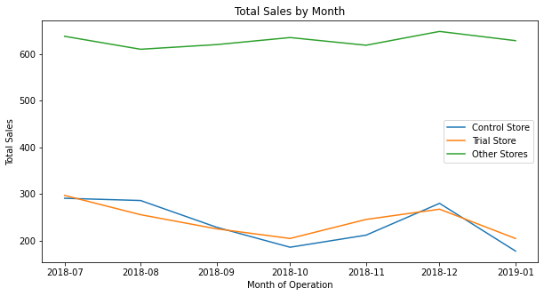

```python
# Plot total sales by month for all 3 types of stores

plt.figure(figsize = (10, 5))
plt.plot(combineSalesPlot)
plt.title('Total Sales by Month')
plt.xlabel('Month of Operation')
plt.ylabel('Total Sales')
plt.legend(['Control Store', 'Trial Store', 'Other Stores'], loc = 5)
```

```python
# Do the same for CUSTOMERS
controlCustomersPlot = pastSales.loc[pastSales['store_type'] == 'Control Store', ['TransactionMonth', 'CUSTOMERS']]
controlCustomersPlot.set_index('TransactionMonth', inplace = True)
controlCustomersPlot.rename(columns = {'CUSTOMERS': 'Control Store'}, inplace = True)

trialCustomersPlot = pastSales.loc[pastSales['store_type'] == 'Trial Store', ['TransactionMonth', 'CUSTOMERS']]
trialCustomersPlot.set_index('TransactionMonth', inplace = True)
trialCustomersPlot.rename(columns = {'CUSTOMERS': 'Trial Store'}, inplace = True)

otherCustomersPlot = pastSales.loc[pastSales['store_type'] == 'Other Stores', ['TransactionMonth', 'CUSTOMERS']]
otherCustomersPlot = pd.DataFrame(otherCustomersPlot.groupby('TransactionMonth').CUSTOMERS.mean())
otherCustomersPlot.rename(columns = {'CUSTOMERS': 'Other Stores'}, inplace = True)

# Concatenate
combineCustomersPlot = pd.concat([controlCustomersPlot, trialCustomersPlot, otherCustomersPlot], axis = 1)
combineCustomersPlot
```

| TransactionMonth | Control Store | Trial Store | Other Stores |
| --- | --- | --- | --- |
| 2018-07-01 | 51 | 51 | 72.333333 |
| 2018-08-01 | 48 | 47 | 72.120155 |
| 2018-09-01 | 42 | 42 | 70.131783 |
| 2018-10-01 | 35 | 37 | 71.608527 |
| 2018-11-01 | 40 | 41 | 70.534884 |
| 2018-12-01 | 47 | 46 | 73.515504 |
| 2019-01-01 | 35 | 35 | 71.240310 |

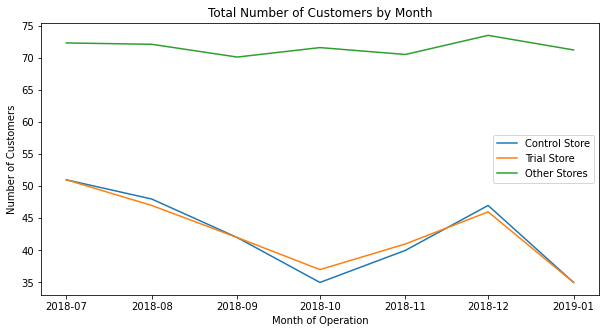

```python
# Plot total number of customers for all 3 types of stores

plt.figure(figsize = (10, 5))
plt.plot(combineCustomersPlot)
plt.title('Total Number of Customers by Month')
plt.xlabel('Month of Operation')
plt.ylabel('Number of Customers')
plt.legend(['Control Store', 'Trial Store', 'Other Stores'], loc = 5)
```